[Edit on GitHub](https://github.com/arviz-devs/ArviZ.jl/blob/main/docs/src/quickstart.jl)

# ArviZ.jl Quickstart

Note

This tutorial is adapted from [ArviZ's quickstart](https://python.arviz.org/en/latest/getting_started/Introduction.html).

## Setup

Here we add the necessary packages for this notebook and load a few we will use throughout.

```julia
using ArviZ, CmdStan, Distributions, LinearAlgebra, PyPlot, Random, Turing
```

```julia
# ArviZ ships with style sheets!
ArviZ.use_style("arviz-darkgrid")
```

## Get started with plotting

ArviZ.jl is designed to be used with libraries like [CmdStan](https://github.com/StanJulia/CmdStan.jl), [Turing.jl](https://turing.ml), and Soss.jl but works fine with raw arrays.

```julia
rng1 = Random.MersenneTwister(37772);
```

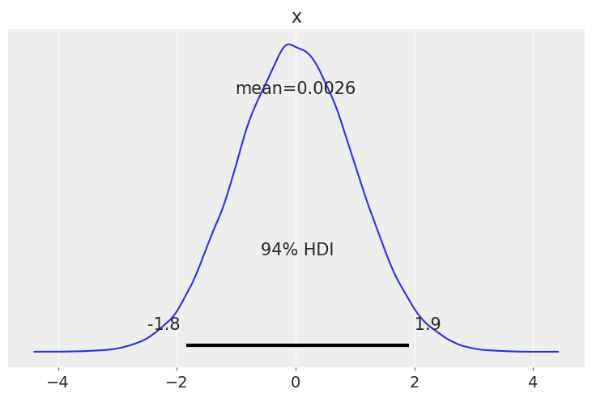

```julia
begin
    plot_posterior(randn(rng1, 100_000))
    gcf()
end
```

Plotting a dictionary of arrays, ArviZ.jl will interpret each key as the name of a different random variable. Each row of an array is treated as an independent series of draws from the variable, called a *chain*. Below, we have 10 chains of 50 draws each for four different distributions.

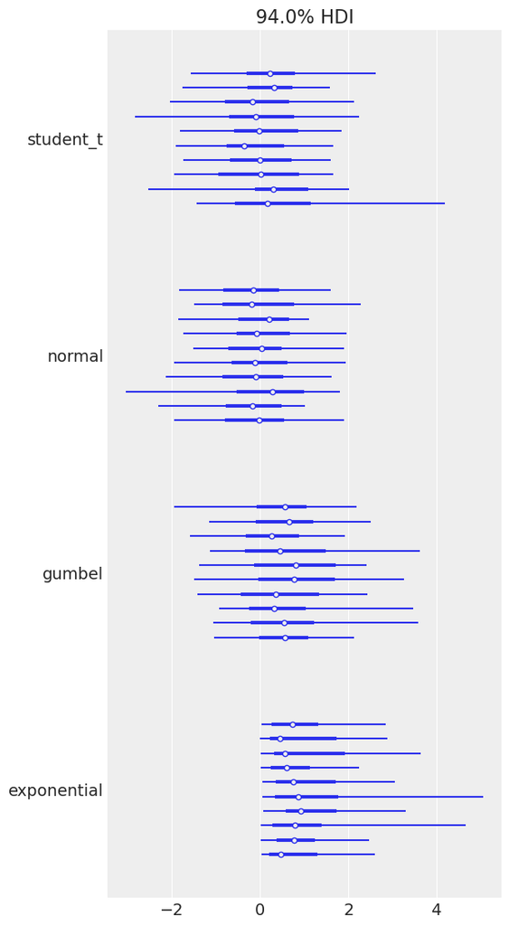

```julia
let
    s = (50, 10)
    plot_forest((
        normal=randn(rng1, s),
        gumbel=rand(rng1, Gumbel(), s),
        student_t=rand(rng1, TDist(6), s),
        exponential=rand(rng1, Exponential(), s),
    ),)
    gcf()
end
```

## Plotting with MCMCChains.jl's `Chains` objects produced by Turing.jl

ArviZ is designed to work well with high dimensional, labelled data. Consider the [eight schools model](https://statmodeling.stat.columbia.edu/2014/01/21/everything-need-know-bayesian-statistics-learned-eight-schools/), which roughly tries to measure the effectiveness of SAT classes at eight different schools. To show off ArviZ's labelling, I give the schools the names of [a different eight schools](https://en.wikipedia.org/wiki/Eight_Schools_Association).

This model is small enough to write down, is hierarchical, and uses labelling. Additionally, a centered parameterization causes [divergences](https://mc-stan.org/users/documentation/case-studies/divergences_and_bias.html) (which are interesting for illustration).

First we create our data and set some sampling parameters.

```julia
begin
    J = 8
    y = [28.0, 8.0, -3.0, 7.0, -1.0, 1.0, 18.0, 12.0]
    σ = [15.0, 10.0, 16.0, 11.0, 9.0, 11.0, 10.0, 18.0]
    schools = [
        "Choate",
        "Deerfield",
        "Phillips Andover",
        "Phillips Exeter",
        "Hotchkiss",
        "Lawrenceville",
        "St. Paul's",
        "Mt. Hermon",
    ]
    ndraws = 1_000
    ndraws_warmup = 1_000
    nchains = 4
end;
```

Now we write and run the model using Turing:

```julia
Turing.@model function model_turing(y, σ, J=length(y))
    μ ~ Normal(0, 5)
    τ ~ truncated(Cauchy(0, 5), 0, Inf)
    θ ~ filldist(Normal(μ, τ), J)
    for i in 1:J
        y[i] ~ Normal(θ[i], σ[i])
    end
end
```

```
model_turing (generic function with 3 methods)
```

```julia
rng2 = Random.MersenneTwister(16653);
```

```julia
begin
    param_mod_turing = model_turing(y, σ)
    sampler = NUTS(ndraws_warmup, 0.8)

    turing_chns = Turing.sample(
        rng2, model_turing(y, σ), sampler, MCMCThreads(), ndraws, nchains
    )
end;
```

Most ArviZ functions work fine with `Chains` objects from Turing:

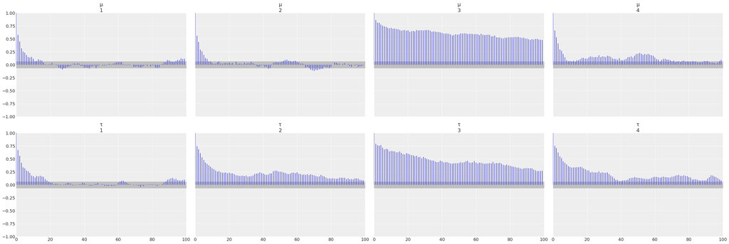

```julia
begin
    plot_autocorr(turing_chns; var_names=(:μ, :τ))
    gcf()
end
```

### Convert to `InferenceData`

For much more powerful querying, analysis and plotting, we can use built-in ArviZ utilities to convert `Chains` objects to multidimensional data structures with named dimensions and indices. Note that for such dimensions, the information is not contained in `Chains`, so we need to provide it.

ArviZ is built to work with [`InferenceData`](https://julia.arviz.org/stable/reference/#ArviZ.InferenceData), and the more *groups* it has access to, the more powerful analyses it can perform.

```julia
idata_turing_post = from_mcmcchains(
    turing_chns;
    coords=(; school=schools),
    dims=NamedTuple(k => (:school,) for k in (:y, :σ, :θ)),
    library="Turing",
)
```

InferenceData

**posterior**

```
Dataset with dimensions:
  Dim{:draw} Sampled{Int64} Base.OneTo(1000) ForwardOrdered Regular Points,
  Dim{:chain} Sampled{Int64} Base.OneTo(4) ForwardOrdered Regular Points,
  Dim{:school} Categorical{String} String[Choate, Deerfield, …, St. Paul's, Mt. Hermon] Unordered
and 3 layers:
  :μ Float64 dims: Dim{:draw}, Dim{:chain} (1000×4)
  :τ Float64 dims: Dim{:draw}, Dim{:chain} (1000×4)
  :θ Float64 dims: Dim{:school}, Dim{:draw}, Dim{:chain} (8×1000×4)

with metadata Dict{String, Any} with 2 entries:
  "created_at" => "2022-12-30T13:40:22.627"
  "inference_library" => "Turing"
```

**sample_stats**

```
Dataset with dimensions:
  Dim{:draw} Sampled{Int64} Base.OneTo(1000) ForwardOrdered Regular Points,
  Dim{:chain} Sampled{Int64} Base.OneTo(4) ForwardOrdered Regular Points
and 12 layers:
  :energy           Float64 dims: Dim{:draw}, Dim{:chain} (1000×4)
  :n_steps          Int64 dims: Dim{:draw}, Dim{:chain} (1000×4)
  :diverging        Bool dims: Dim{:draw}, Dim{:chain} (1000×4)
  :max_energy_error Float64 dims: Dim{:draw}, Dim{:chain} (1000×4)
  :energy_error     Float64 dims: Dim{:draw}, Dim{:chain} (1000×4)
  :is_accept        Bool dims: Dim{:draw}, Dim{:chain} (1000×4)
  :log_density      Float64 dims: Dim{:draw}, Dim{:chain} (1000×4)
  :tree_depth       Int64 dims: Dim{:draw}, Dim{:chain} (1000×4)
  :step_size        Float64 dims: Dim{:draw}, Dim{:chain} (1000×4)
  :acceptance_rate  Float64 dims: Dim{:draw}, Dim{:chain} (1000×4)
  :lp               Float64 dims: Dim{:draw}, Dim{:chain} (1000×4)
  :step_size_nom    Float64 dims: Dim{:draw}, Dim{:chain} (1000×4)

with metadata Dict{String, Any} with 2 entries:
  "created_at" => "2022-12-30T13:40:22.361"
  "inference_library" => "Turing"
```

Each group is an [`ArviZ.Dataset`](https://julia.arviz.org/stable/reference/#ArviZ.Dataset), a `DimensionalData.AbstractDimStack` that can be used identically to a [`DimensionalData.Dimstack`](https://rafaqz.github.io/DimensionalData.jl/stable/api/#DimensionalData.DimStack). We can view a summary of the dataset.

```julia
idata_turing_post.posterior
```

```
Dataset with dimensions:
  Dim{:draw} Sampled{Int64} Base.OneTo(1000) ForwardOrdered Regular Points,
  Dim{:chain} Sampled{Int64} Base.OneTo(4) ForwardOrdered Regular Points,
  Dim{:school} Categorical{String} String[Choate, Deerfield, …, St. Paul's, Mt. Hermon] Unordered
and 3 layers:
  :μ Float64 dims: Dim{:draw}, Dim{:chain} (1000×4)
  :τ Float64 dims: Dim{:draw}, Dim{:chain} (1000×4)
  :θ Float64 dims: Dim{:school}, Dim{:draw}, Dim{:chain} (8×1000×4)

with metadata Dict{String, Any} with 2 entries:
  "created_at"        => "2022-12-30T13:40:22.627"
  "inference_library" => "Turing"
```

Here is a plot of the trace. Note the intelligent labels.

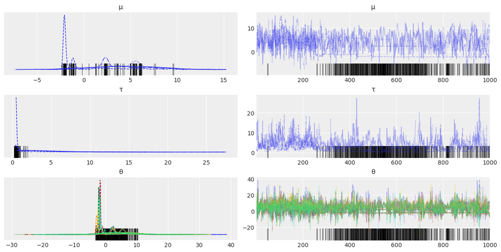

```julia
begin
    plot_trace(idata_turing_post)
    gcf()
end
```

We can also generate summary stats...

```julia
summarystats(idata_turing_post)
```

|  | variable | mean | sd | hdi_3% | hdi_97% | mcse_mean | mcse_sd | ess_bulk | ess_tail | r_hat |
| --- | --- | --- | --- | --- | --- | --- | --- | --- | --- | --- |
| 1 | "μ" | 3.138 | 3.839 | -2.317 | 9.662 | 1.078 | 0.78 | 13.0 | 6.0 | 1.22 |
| 2 | "τ" | 3.032 | 3.133 | 0.3 | 8.646 | 0.617 | 0.441 | 13.0 | 11.0 | 1.22 |
| 3 | "θ[Choate]" | 4.586 | 6.117 | -4.145 | 15.856 | 1.388 | 0.997 | 15.0 | 7.0 | 1.19 |
| 4 | "θ[Deerfield]" | 3.51 | 5.04 | -2.884 | 13.888 | 1.265 | 0.911 | 15.0 | 6.0 | 1.19 |
| 5 | "θ[Phillips Andover]" | 2.743 | 5.244 | -5.228 | 13.027 | 0.97 | 0.693 | 25.0 | 1063.0 | 1.11 |
| 6 | "θ[Phillips Exeter]" | 3.489 | 5.043 | -4.124 | 13.586 | 1.085 | 0.778 | 21.0 | 1251.0 | 1.13 |
| 7 | "θ[Hotchkiss]" | 2.601 | 4.687 | -4.124 | 12.224 | 0.932 | 0.667 | 25.0 | 1085.0 | 1.11 |
| 8 | "θ[Lawrenceville]" | 2.839 | 4.929 | -4.635 | 12.842 | 0.963 | 0.688 | 22.0 | 1084.0 | 1.12 |
| 9 | "θ[St. Paul's]" | 4.771 | 5.787 | -2.462 | 16.072 | 1.496 | 1.08 | 12.0 | 6.0 | 1.24 |
| 10 | "θ[Mt. Hermon]" | 3.476 | 5.513 | -4.79 | 14.479 | 1.085 | 0.776 | 21.0 | 1364.0 | 1.13 |

...and examine the energy distribution of the Hamiltonian sampler.

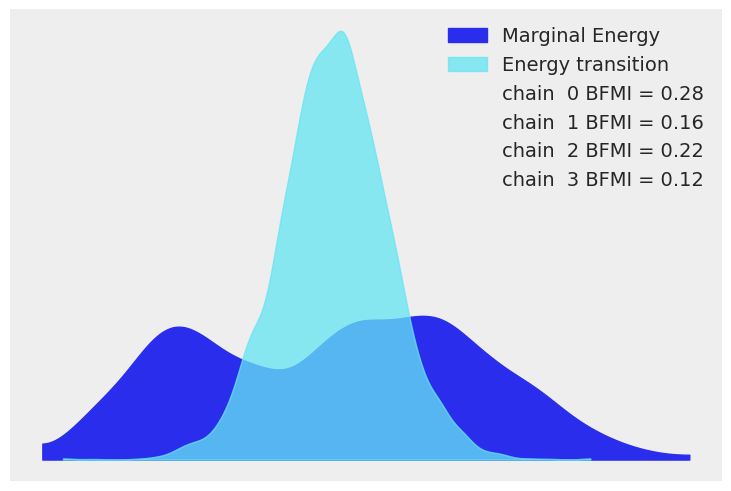

```julia
begin
    plot_energy(idata_turing_post)
    gcf()
end
```

### Additional information in Turing.jl

With a few more steps, we can use Turing to compute additional useful groups to add to the `InferenceData`.

To sample from the prior, one simply calls `sample` but with the `Prior` sampler:

```julia
prior = Turing.sample(rng2, param_mod_turing, Prior(), ndraws);
```

To draw from the prior and posterior predictive distributions we can instantiate a "predictive model", i.e. a Turing model but with the observations set to `missing`, and then calling `predict` on the predictive model and the previously drawn samples:

```julia
begin
    # Instantiate the predictive model
    param_mod_predict = model_turing(similar(y, Missing), σ)
    # and then sample!
    prior_predictive = Turing.predict(rng2, param_mod_predict, prior)
    posterior_predictive = Turing.predict(rng2, param_mod_predict, turing_chns)
end;
```

And to extract the pointwise log-likelihoods, which is useful if you want to compute metrics such as [`loo`](https://julia.arviz.org/stable/reference/#ArviZ.loo),

```julia
log_likelihood = let
    log_likelihood = Turing.pointwise_loglikelihoods(
        param_mod_turing, MCMCChains.get_sections(turing_chns, :parameters)
    )
    # Ensure the ordering of the loglikelihoods matches the ordering of `posterior_predictive`
    ynames = string.(keys(posterior_predictive))
    log_likelihood_y = getindex.(Ref(log_likelihood), ynames)
    # Reshape into `(size(y)..., ndraws, nchains)`
    (; y=permutedims(cat(log_likelihood_y...; dims=3), (3, 1, 2)))
end;
```

This can then be included in the [`from_mcmcchains`](https://julia.arviz.org/stable/reference/#ArviZ.from_mcmcchains) call from above:

```julia
idata_turing = from_mcmcchains(
    turing_chns;
    posterior_predictive,
    log_likelihood,
    prior,
    prior_predictive,
    observed_data=(; y),
    coords=(; school=schools),
    dims=NamedTuple(k => (:school,) for k in (:y, :σ, :θ)),
    library=Turing,
)
```

InferenceData

**posterior**

```
Dataset with dimensions:
  Dim{:draw} Sampled{Int64} Base.OneTo(1000) ForwardOrdered Regular Points,
  Dim{:chain} Sampled{Int64} Base.OneTo(4) ForwardOrdered Regular Points,
  Dim{:school} Categorical{String} String[Choate, Deerfield, …, St. Paul's, Mt. Hermon] Unordered
and 3 layers:
  :μ Float64 dims: Dim{:draw}, Dim{:chain} (1000×4)
  :τ Float64 dims: Dim{:draw}, Dim{:chain} (1000×4)
  :θ Float64 dims: Dim{:school}, Dim{:draw}, Dim{:chain} (8×1000×4)

with metadata Dict{String, Any} with 3 entries:
  "created_at" => "2022-12-30T13:40:45.691"
  "inference_library_version" => "0.21.13"
  "inference_library" => "Turing"
```

**posterior_predictive**

```
Dataset with dimensions:
  Dim{:school} Categorical{String} String[Choate, Deerfield, …, St. Paul's, Mt. Hermon] Unordered,
  Dim{:draw} Sampled{Int64} Base.OneTo(1000) ForwardOrdered Regular Points,
  Dim{:chain} Sampled{Int64} Base.OneTo(4) ForwardOrdered Regular Points
and 1 layer:
  :y Float64 dims: Dim{:school}, Dim{:draw}, Dim{:chain} (8×1000×4)

with metadata Dict{String, Any} with 3 entries:
  "created_at" => "2022-12-30T13:40:45.145"
  "inference_library_version" => "0.21.13"
  "inference_library" => "Turing"
```

**log_likelihood**

```
Dataset with dimensions:
  Dim{:school} Categorical{String} String[Choate, Deerfield, …, St. Paul's, Mt. Hermon] Unordered,
  Dim{:draw} Sampled{Int64} Base.OneTo(1000) ForwardOrdered Regular Points,
  Dim{:chain} Sampled{Int64} Base.OneTo(4) ForwardOrdered Regular Points
and 1 layer:
  :y Float64 dims: Dim{:school}, Dim{:draw}, Dim{:chain} (8×1000×4)

with metadata Dict{String, Any} with 3 entries:
  "created_at" => "2022-12-30T13:40:45.465"
  "inference_library_version" => "0.21.13"
  "inference_library" => "Turing"
```

**sample_stats**

```
Dataset with dimensions:
  Dim{:draw} Sampled{Int64} Base.OneTo(1000) ForwardOrdered Regular Points,
  Dim{:chain} Sampled{Int64} Base.OneTo(4) ForwardOrdered Regular Points
and 12 layers:
  :energy           Float64 dims: Dim{:draw}, Dim{:chain} (1000×4)
  :n_steps          Int64 dims: Dim{:draw}, Dim{:chain} (1000×4)
  :diverging        Bool dims: Dim{:draw}, Dim{:chain} (1000×4)
  :max_energy_error Float64 dims: Dim{:draw}, Dim{:chain} (1000×4)
  :energy_error     Float64 dims: Dim{:draw}, Dim{:chain} (1000×4)
  :is_accept        Bool dims: Dim{:draw}, Dim{:chain} (1000×4)
  :log_density      Float64 dims: Dim{:draw}, Dim{:chain} (1000×4)
  :tree_depth       Int64 dims: Dim{:draw}, Dim{:chain} (1000×4)
  :step_size        Float64 dims: Dim{:draw}, Dim{:chain} (1000×4)
  :acceptance_rate  Float64 dims: Dim{:draw}, Dim{:chain} (1000×4)
  :lp               Float64 dims: Dim{:draw}, Dim{:chain} (1000×4)
  :step_size_nom    Float64 dims: Dim{:draw}, Dim{:chain} (1000×4)

with metadata Dict{String, Any} with 3 entries:
  "created_at" => "2022-12-30T13:40:45.691"
  "inference_library_version" => "0.21.13"
  "inference_library" => "Turing"
```

**prior**

```
Dataset with dimensions:
  Dim{:draw} Sampled{Int64} Base.OneTo(1000) ForwardOrdered Regular Points,
  Dim{:chain} Sampled{Int64} Base.OneTo(1) ForwardOrdered Regular Points,
  Dim{:school} Categorical{String} String[Choate, Deerfield, …, St. Paul's, Mt. Hermon] Unordered
and 3 layers:
  :μ Float64 dims: Dim{:draw}, Dim{:chain} (1000×1)
  :τ Float64 dims: Dim{:draw}, Dim{:chain} (1000×1)
  :θ Float64 dims: Dim{:school}, Dim{:draw}, Dim{:chain} (8×1000×1)

with metadata Dict{String, Any} with 3 entries:
  "created_at" => "2022-12-30T13:40:46.845"
  "inference_library_version" => "0.21.13"
  "inference_library" => "Turing"
```

**prior_predictive**

```
Dataset with dimensions:
  Dim{:school} Categorical{String} String[Choate, Deerfield, …, St. Paul's, Mt. Hermon] Unordered,
  Dim{:draw} Sampled{Int64} Base.OneTo(1000) ForwardOrdered Regular Points,
  Dim{:chain} Sampled{Int64} Base.OneTo(1) ForwardOrdered Regular Points
and 1 layer:
  :y Float64 dims: Dim{:school}, Dim{:draw}, Dim{:chain} (8×1000×1)

with metadata Dict{String, Any} with 3 entries:
  "created_at" => "2022-12-30T13:40:46.379"
  "inference_library_version" => "0.21.13"
  "inference_library" => "Turing"
```

**sample_stats_prior**

```
Dataset with dimensions:
  Dim{:draw} Sampled{Int64} Base.OneTo(1000) ForwardOrdered Regular Points,
  Dim{:chain} Sampled{Int64} Base.OneTo(1) ForwardOrdered Regular Points
and 1 layer:
  :lp Float64 dims: Dim{:draw}, Dim{:chain} (1000×1)

with metadata Dict{String, Any} with 3 entries:
  "created_at" => "2022-12-30T13:40:46.587"
  "inference_library_version" => "0.21.13"
  "inference_library" => "Turing"
```

**observed_data**

```
Dataset with dimensions:
  Dim{:school} Categorical{String} String[Choate, Deerfield, …, St. Paul's, Mt. Hermon] Unordered
and 1 layer:
  :y Float64 dims: Dim{:school} (8)

with metadata Dict{String, Any} with 3 entries:
  "created_at" => "2022-12-30T13:40:47.232"
  "inference_library_version" => "0.21.13"
  "inference_library" => "Turing"
```

Then we can for example compute the expected *leave-one-out (LOO)* predictive density, which is an estimate of the out-of-distribution predictive fit of the model:

```julia
loo(idata_turing; pointwise=false) # higher is better
```

|  | elpd_loo | se | p_loo | n_samples | n_data_points | warning | scale |
| --- | --- | --- | --- | --- | --- | --- | --- |
| 1 | -31.2342 | 1.59735 | 1.05766 | 4000 | 8 | true | "log" |

If the model is well-calibrated, i.e. it replicates the true generative process well, the CDF of the pointwise LOO values should be similarly distributed to a uniform distribution. This can be inspected visually:

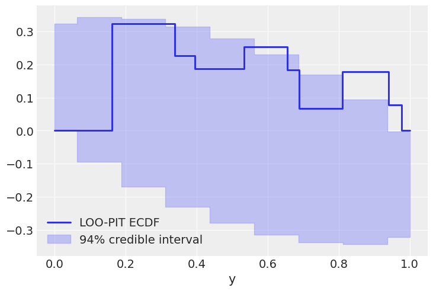

```julia
begin
    plot_loo_pit(idata_turing; y=:y, ecdf=true)
    gcf()
end
```

## Plotting with CmdStan.jl outputs

CmdStan.jl and StanSample.jl also default to producing `Chains` outputs, and we can easily plot these chains.

Here is the same centered eight schools model:

```julia
begin
    schools_code = """
    data {
      int<lower=0> J;
      real y[J];
      real<lower=0> sigma[J];
    }

    parameters {
      real mu;
      real<lower=0> tau;
      real theta[J];
    }

    model {
      mu ~ normal(0, 5);
      tau ~ cauchy(0, 5);
      theta ~ normal(mu, tau);
      y ~ normal(theta, sigma);
    }

    generated quantities {
        vector[J] log_lik;
        vector[J] y_hat;
        for (j in 1:J) {
            log_lik[j] = normal_lpdf(y[j] | theta[j], sigma[j]);
            y_hat[j] = normal_rng(theta[j], sigma[j]);
        }
    }
    """

    schools_data = Dict("J" => J, "y" => y, "sigma" => σ)
    stan_chns = mktempdir() do path
        stan_model = Stanmodel(;
            model=schools_code,
            name="schools",
            nchains,
            num_warmup=ndraws_warmup,
            num_samples=ndraws,
            output_format=:mcmcchains,
            random=CmdStan.Random(28983),
            tmpdir=path,
        )
        _, chns, _ = stan(stan_model, schools_data; summary=false)
        return chns
    end
end;
```

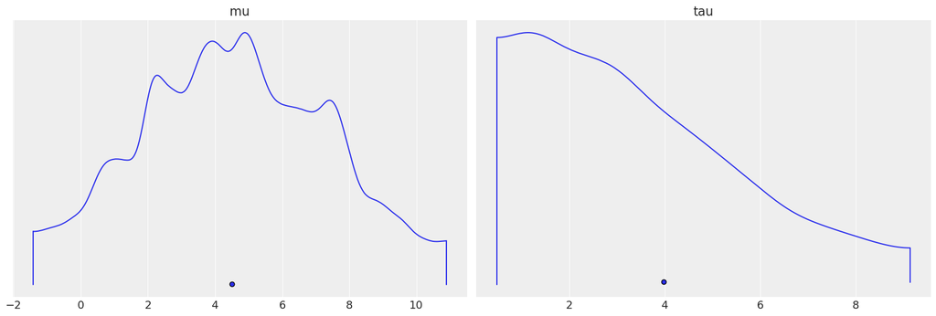

```julia
begin
    plot_density(stan_chns; var_names=(:mu, :tau))
    gcf()
end
```

Again, converting to `InferenceData`, we can get much richer labelling and mixing of data. Note that we're using the same [`from_cmdstan`](https://julia.arviz.org/stable/reference/#ArviZ.from_cmdstan) function used by ArviZ to process cmdstan output files, but through the power of dispatch in Julia, if we pass a `Chains` object, it instead uses ArviZ.jl's overloads, which forward to `from_mcmcchains`.

```julia
idata_stan = from_cmdstan(
    stan_chns;
    posterior_predictive=:y_hat,
    observed_data=(; y),
    log_likelihood=:log_lik,
    coords=(; school=schools),
    dims=NamedTuple(k => (:school,) for k in (:y, :sigma, :theta, :log_lik, :y_hat)),
)
```

InferenceData

**posterior**

```
Dataset with dimensions:
  Dim{:draw} Sampled{Int64} Base.OneTo(1000) ForwardOrdered Regular Points,
  Dim{:chain} Sampled{Int64} Base.OneTo(4) ForwardOrdered Regular Points,
  Dim{:school} Categorical{String} String[Choate, Deerfield, …, St. Paul's, Mt. Hermon] Unordered
and 3 layers:
  :mu    Float64 dims: Dim{:draw}, Dim{:chain} (1000×4)
  :theta Float64 dims: Dim{:school}, Dim{:draw}, Dim{:chain} (8×1000×4)
  :tau   Float64 dims: Dim{:draw}, Dim{:chain} (1000×4)

with metadata Dict{String, Any} with 2 entries:
  "created_at" => "2022-12-30T13:41:25.905"
  "inference_library" => "CmdStan"
```

**posterior_predictive**

```
Dataset with dimensions:
  Dim{:school} Categorical{String} String[Choate, Deerfield, …, St. Paul's, Mt. Hermon] Unordered,
  Dim{:draw} Sampled{Int64} Base.OneTo(1000) ForwardOrdered Regular Points,
  Dim{:chain} Sampled{Int64} Base.OneTo(4) ForwardOrdered Regular Points
and 1 layer:
  :y_hat Float64 dims: Dim{:school}, Dim{:draw}, Dim{:chain} (8×1000×4)

with metadata Dict{String, Any} with 2 entries:
  "created_at" => "2022-12-30T13:41:25.133"
  "inference_library" => "CmdStan"
```

**log_likelihood**

```
Dataset with dimensions:
  Dim{:school} Categorical{String} String[Choate, Deerfield, …, St. Paul's, Mt. Hermon] Unordered,
  Dim{:draw} Sampled{Int64} Base.OneTo(1000) ForwardOrdered Regular Points,
  Dim{:chain} Sampled{Int64} Base.OneTo(4) ForwardOrdered Regular Points
and 1 layer:
  :log_lik Float64 dims: Dim{:school}, Dim{:draw}, Dim{:chain} (8×1000×4)

with metadata Dict{String, Any} with 2 entries:
  "created_at" => "2022-12-30T13:41:25.482"
  "inference_library" => "CmdStan"
```

**sample_stats**

```
Dataset with dimensions:
  Dim{:draw} Sampled{Int64} Base.OneTo(1000) ForwardOrdered Regular Points,
  Dim{:chain} Sampled{Int64} Base.OneTo(4) ForwardOrdered Regular Points
and 7 layers:
  :tree_depth      Int64 dims: Dim{:draw}, Dim{:chain} (1000×4)
  :n_steps         Int64 dims: Dim{:draw}, Dim{:chain} (1000×4)
  :lp              Float64 dims: Dim{:draw}, Dim{:chain} (1000×4)
  :step_size       Float64 dims: Dim{:draw}, Dim{:chain} (1000×4)
  :energy          Float64 dims: Dim{:draw}, Dim{:chain} (1000×4)
  :diverging       Bool dims: Dim{:draw}, Dim{:chain} (1000×4)
  :acceptance_rate Float64 dims: Dim{:draw}, Dim{:chain} (1000×4)

with metadata Dict{String, Any} with 2 entries:
  "created_at" => "2022-12-30T13:41:25.905"
  "inference_library" => "CmdStan"
```

**observed_data**

```
Dataset with dimensions:
  Dim{:school} Categorical{String} String[Choate, Deerfield, …, St. Paul's, Mt. Hermon] Unordered
and 1 layer:
  :y Float64 dims: Dim{:school} (8)

with metadata Dict{String, Any} with 2 entries:
  "created_at" => "2022-12-30T13:41:26.339"
  "inference_library" => "CmdStan"
```

Here is a plot showing where the Hamiltonian sampler had divergences:

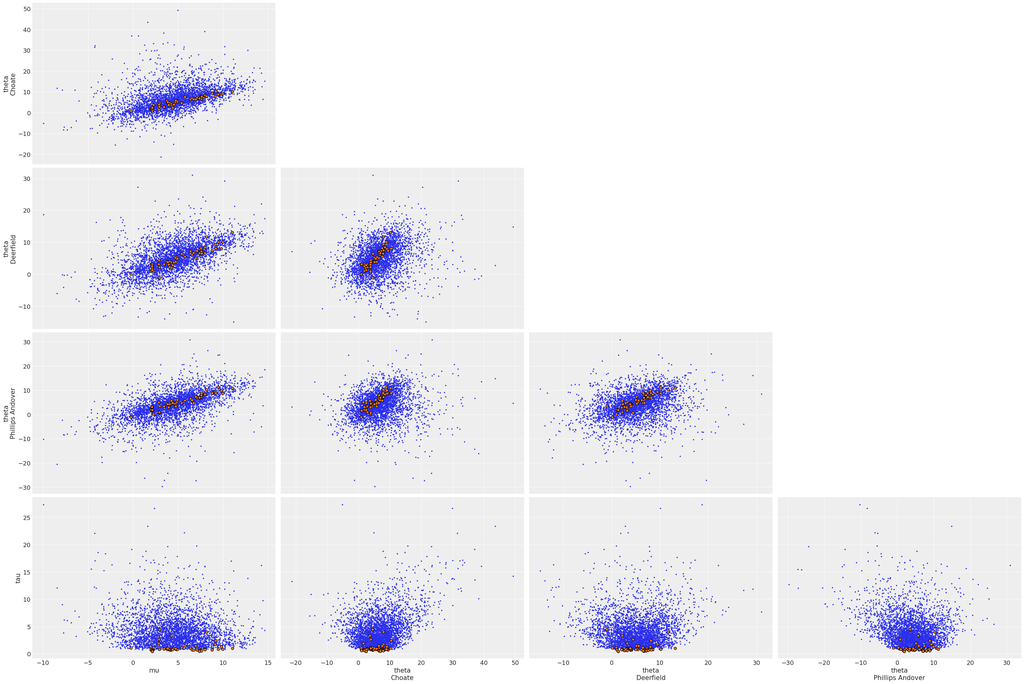

```julia
begin
    plot_pair(
        idata_stan;
        coords=Dict(:school => ["Choate", "Deerfield", "Phillips Andover"]),
        divergences=true,
    )
    gcf()
end
```

## Environment

```julia
using PlutoUI
```

```julia
using Pkg, InteractiveUtils
```

```julia
with_terminal(Pkg.status; color=false)
```

```
Status `~/work/ArviZ.jl/ArviZ.jl/docs/Project.toml`
⌃ [cbdf2221] AlgebraOfGraphics v0.6.12
  [131c737c] ArviZ v0.7.1 `~/work/ArviZ.jl/ArviZ.jl`
⌅ [13f3f980] CairoMakie v0.9.4
  [593b3428] CmdStan v6.6.0
  [a93c6f00] DataFrames v1.4.4
⌅ [0703355e] DimensionalData v0.23.2
  [31c24e10] Distributions v0.25.79
  [e30172f5] Documenter v0.27.23
  [c7f686f2] MCMCChains v5.6.1
  [359b1769] PlutoStaticHTML v6.0.8
  [7f904dfe] PlutoUI v0.7.49
  [438e738f] PyCall v1.94.1
  [d330b81b] PyPlot v2.11.0
  [754583d1] SampleChains v0.5.1
⌅ [fce5fe82] Turing v0.21.13
  [f43a241f] Downloads v1.6.0
  [37e2e46d] LinearAlgebra
Info Packages marked with ⌃ and ⌅ have new versions available, but those with ⌅ are restricted by compatibility constraints from upgrading. To see why use `status --outdated`
```

```julia
with_terminal(versioninfo)
```

```
Julia Version 1.8.4
Commit 00177ebc4fc (2022-12-23 21:32 UTC)
Platform Info:
  OS: Linux (x86_64-linux-gnu)
  CPU: 2 × Intel(R) Xeon(R) Platinum 8370C CPU @ 2.80GHz
  WORD_SIZE: 64
  LIBM: libopenlibm
  LLVM: libLLVM-13.0.1 (ORCJIT, icelake-server)
  Threads: 2 on 2 virtual cores
Environment:
  JULIA_NUM_THREADS = 2
  JULIA_CMDSTAN_HOME = /home/runner/work/ArviZ.jl/ArviZ.jl/.cmdstan//cmdstan-2.25.0/
  JULIA_REVISE_WORKER_ONLY = 1
```